# R Notebook

## Basic Commands

```r
x <- c(1, 3, 2, 5)
x
```

```
[1] 1 3 2 5
```

Kita juga bisa menggunakan tanda ‘=’ menggantikan assignment ‘<-’

```r
y = c(2, 3, 4, 5)
y
```

```
[1] 2 3 4 5
```

Kita pun dapat menambahkan x dan y dan nilainya akan bertambah secara otomatis

```r
x + y
```

```
[1]  4  6  8 10
```

```r
length(x)
```

```
[1] 4
```

```r
length(y)
```

```
[1] 4
```

R juga memiliki fitur seperti ls() dan rm() yang masing masing bertujuan untuk melakukan list terhadap obejct apa saja yang sudah ada dan rm() berfungsi untuk menghapus object

```r
ls()
```

```
[1] "x" "y"
```

```r
#rm(a, b, formula)
#ls()
```

lalu kita menghapus objeck tersebut dengan rm()

```r
rm(x, y)
ls()
```

```
character(0)
```

jika kita mempunyai banyak objek, misalkan ada 5 objek maka kita dapat menggunakan perintah gabungan list() dan rm() untuk menghapus semuanya sekaligus.

```r
x <- 5
y <- 10
z <- c(1, 2, 3)
ls()
```

```
[1] "x" "y" "z"
```

kita hapus dengan perintah berikut

```r
rm(list=ls())
ls()
```

```
character(0)
```

sekarang kita akan memfokuskan pada penggunaan matrix.

```r
?matrix # perintah untuk membaca dokumen matrix
x=matrix(data=c(1, 2, 3, 4), nrow=2, ncol=2)
x
```

```
     [,1] [,2]
[1,]    1    3
[2,]    2    4
```

kita juga dapat memanggil perintah matrix dengan menghilangkan nrow dan ncol

```r
x=matrix(data=c(1, 2, 3, 4),2, 2)
x
```

```
     [,1] [,2]
[1,]    1    3
[2,]    2    4
```

kita pun dapat menggunkan argumen byrow=TRUE agar matrix tersusun secara baris. Jika kita tidak menspesifikkan argumen byrow, maka secara default byrow bernilai FALSE

```r
x=matrix(data=c(1, 2, 3, 4), nrow=2, ncol=2, byrow=TRUE)
x
```

```
     [,1] [,2]
[1,]    1    2
[2,]    3    4
```

silahkan dilihat perbedaannya. Terjadi perbedaan susunan. Sekarang kita akan mencoba untuk mengoperasikan fungsi sqrt() dan power of two ke matrix x.

```r
sqrt(x)
```

```
         [,1]     [,2]
[1,] 1.000000 1.414214
[2,] 1.732051 2.000000
```

```r
x
```

```
     [,1] [,2]
[1,]    1    2
[2,]    3    4
```

```r
x^2
```

```
     [,1] [,2]
[1,]    1    4
[2,]    9   16
```

```r
x
```

```
     [,1] [,2]
[1,]    1    2
[2,]    3    4
```

perhatikan perbedaanya. ketika kita mengoperasikan sqrt(x), tidak ada objek yang tercipta. Maka dari itu kita harus selalu menggassign nilai hasil operasi ke sesuatu tempat.

r juga mempunya fungsi rnorm() untuk menghasilkan angka random dalam bentuk vektor. selain itu ada juga fungsi cor() untuk menghitung korelasi antar variabel.

```r
x=rnorm(100)
x
```

```
  [1]  0.174997783 -1.272478966 -0.888553330  0.744806178  0.699892049 -0.433773668  0.834668810
  [8]  0.549215736  0.200069691 -0.792690863 -0.161289845 -1.228812255  1.453581392  1.414077982
 [15]  0.045971859 -0.228465726 -0.387437871  0.502909614 -1.430347227  1.315578237 -0.352421575
 [22]  0.393988278  0.544571584  0.701149698  0.007220694  0.857876927  0.037237573 -0.021626886
 [29]  1.012766863 -0.396189957 -0.976416942 -1.459717163  1.123253718  1.334253401  0.862882126
 [36]  0.430244571 -0.548813413  0.315561833 -0.732055199  1.803600648 -0.897534557 -0.119755282
 [43] -0.460874439  1.117570128  0.514556562 -0.227337157  1.798021633  0.874723248 -0.784602842
 [50] -1.697761409 -0.514020936 -0.467690369 -0.024849576 -2.688140981  0.315145365 -1.423743113
 [57] -1.092005475  0.291348424 -1.080633576  0.632607959 -0.854775425 -0.418909404  0.240428446
 [64]  0.377308933 -0.894805282 -0.015240457 -2.079611895  0.700569236 -0.250117602  0.436067003
 [71] -0.111158525 -1.692164631  0.732993134  0.066962300 -0.762609507  0.008113311 -0.873156067
 [78]  0.478821198 -0.718072033 -1.151529161 -0.357739369  0.531417817 -0.056945659  1.662239761
 [85] -0.416888798  0.467170363 -0.152827168  2.147589767  0.042926107  1.397289051  1.191153461
 [92] -0.077892132 -1.680741842  0.824585312  1.598320164  0.085351585  0.698137515  0.859967085
 [99]  1.844953339 -0.236568438
```

```r
?rnorm()
y = x + rnorm(100, mean=100, sd=0.1)
y
```

```
  [1] 100.23443  98.56923  99.15702 100.70741 100.71368  99.78395 100.86257 100.50354 100.22728
 [10]  99.16912  99.71474  98.84149 101.57265 101.50906 100.26412  99.86092  99.63981 100.43065
 [19]  98.40273 101.29712  99.74899 100.34631 100.40427 100.61933 100.01212 100.79756  99.99052
 [28] 100.05764 100.86574  99.65402  98.98741  98.62041 101.11727 101.48135 101.03132 100.50059
 [37]  99.57333 100.32070  99.49868 101.74501  99.05793  99.74983  99.50603 101.02501 100.44451
 [46]  99.67419 101.71085 100.89608  99.21479  98.16419  99.61435  99.50888 100.01553  97.18763
 [55] 100.36297  98.62964  98.94419 100.32009  99.00348 100.64900  99.27506  99.61919 100.23817
 [64] 100.36065  99.06736 100.07711  98.03576 100.66036  99.76806 100.39852  99.92345  98.38455
 [73] 100.63136 100.14896  99.20202  99.95189  99.03727 100.50314  99.08168  98.78958  99.76974
 [82] 100.55101  99.83666 101.56020  99.55726 100.38168  99.99505 102.29459 100.05413 101.47675
 [91] 101.20983  99.82243  98.38032 100.77790 101.76470 100.10275 100.63722 100.97242 102.04853
[100]  99.63136
```

```r
# hitung korelasi antara x dan y dengan fungsi cor()
cor(x, y)
```

```
[1] 0.9951425
```

rnorm() membuat angka secara random. namun kita bisa menyamakan angka tersebut dengan mengatur nilai seed menggunakan fungsi set.seed()

```r
set.seed(1303)
rnorm(50)
```

```
 [1] -1.1439763145  1.3421293656  2.1853904757  0.5363925179  0.0631929665  0.5022344825
 [7] -0.0004167247  0.5658198405 -0.5725226890 -1.1102250073 -0.0486871234 -0.6956562176
[13]  0.8289174803  0.2066528551 -0.2356745091 -0.5563104914 -0.3647543571  0.8623550343
[19] -0.6307715354  0.3136021252 -0.9314953177  0.8238676185  0.5233707021  0.7069214120
[25]  0.4202043256 -0.2690521547 -1.5103172999 -0.6902124766 -0.1434719524 -1.0135274099
[31]  1.5732737361  0.0127465055  0.8726470499  0.4220661905 -0.0188157917  2.6157489689
[37] -0.6931401748 -0.2663217810 -0.7206364412  1.3677342065  0.2640073322  0.6321868074
[43] -1.3306509858  0.0268888182  1.0406363208  1.3120237985 -0.0300020767 -0.2500257125
[49]  0.0234144857  1.6598706557
```

r juga memiliki fitur keren seperti menghitung mean, variance, dan standard deviation dengan menggunakan fungsi mean(), var(), dan sd()

```r
set.seed(3)
y = rnorm(100)
mean(y)
```

```
[1] 0.01103557
```

```r
var(y)
```

```
[1] 0.7328675
```

```r
sd(y)
```

```
[1] 0.8560768
```

```r
# sama saja dengan akar dari variansi
sqrt(var(y))
```

```
[1] 0.8560768
```

## Graphics

buku ini tidak menggunakan ggplot2 sebagai fungsi plot melainkan menggunakan plot built-in.

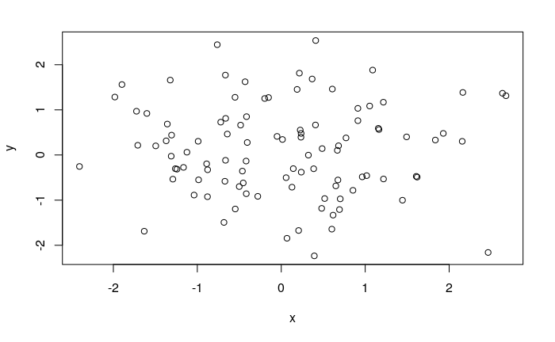

```r
?plot
x = rnorm(100)
y = rnorm(100)
plot(x, y)
```

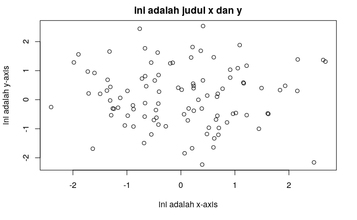

```r
plot(x, y, xlab="ini adalah x-axis", ylab="ini adalah y-axis", main="ini adalah judul x dan y")
```

kita pun bisa menyimpan gambar yang kita ingin plot dengan fungsi berikut

```r
pdf("gambar.pdf")
plot(x, y, col="green")
dev.off()
```

fungsi seq() digunakan untuk menghasilkan sekeuns angka

```r
x = seq(1, 10)
# bisa juga dengan x = 1:10
x
```

```
 [1]  1  2  3  4  5  6  7  8  9 10
```

```r
y = seq(1, 20, length=100)
y
```

```
  [1]  1.000000  1.191919  1.383838  1.575758  1.767677  1.959596  2.151515  2.343434  2.535354
 [10]  2.727273  2.919192  3.111111  3.303030  3.494949  3.686869  3.878788  4.070707  4.262626
 [19]  4.454545  4.646465  4.838384  5.030303  5.222222  5.414141  5.606061  5.797980  5.989899
 [28]  6.181818  6.373737  6.565657  6.757576  6.949495  7.141414  7.333333  7.525253  7.717172
 [37]  7.909091  8.101010  8.292929  8.484848  8.676768  8.868687  9.060606  9.252525  9.444444
 [46]  9.636364  9.828283 10.020202 10.212121 10.404040 10.595960 10.787879 10.979798 11.171717
 [55] 11.363636 11.555556 11.747475 11.939394 12.131313 12.323232 12.515152 12.707071 12.898990
 [64] 13.090909 13.282828 13.474747 13.666667 13.858586 14.050505 14.242424 14.434343 14.626263
 [73] 14.818182 15.010101 15.202020 15.393939 15.585859 15.777778 15.969697 16.161616 16.353535
 [82] 16.545455 16.737374 16.929293 17.121212 17.313131 17.505051 17.696970 17.888889 18.080808
 [91] 18.272727 18.464646 18.656566 18.848485 19.040404 19.232323 19.424242 19.616162 19.808081
[100] 20.000000
```

## Indexing Data

kita bisa menggunakann slicing seperti di python atau menggunakan concatenasi

```r
A = matrix(1:16, nrow=4, ncol=4)
A
```

```
     [,1] [,2] [,3] [,4]
[1,]    1    5    9   13
[2,]    2    6   10   14
[3,]    3    7   11   15
[4,]    4    8   12   16
```

```r
# slicing dengan concatenasi, angka terakhir adalah stopping point
A[c(1, 3), c(2, 4)]
```

```
     [,1] [,2]
[1,]    5   13
[2,]    7   15
```

```r
A[1:3, 3:4]
```

```
     [,1] [,2]
[1,]    9   13
[2,]   10   14
[3,]   11   15
```

## Loading Data

```r
auto = read.table("../dataset/Auto.data")
```

```r
fix(auto)
```

karena dataset Auto.data memiliki missing values, maka kita harus bisa menanganinya. Selain itu kita harus memberikan argumen header=TRUE or header=T agar headernya tidak masuk ke dalam data

```r
auto = read.table("../dataset/Auto.data", header=T, na.strings="?")
fix(auto)
```

kita juga bisa meng-load Auto.csv

```r
auto = read.csv("../dataset/Auto.csv", header=T, na.strings="?")
fix(auto)
dim(auto)
```

```
[1] 392   9
```

```r
# mengecek nama nama variable
names(auto)
```

```
[1] "mpg"          "cylinders"    "displacement" "horsepower"   "weight"       "acceleration"
[7] "year"         "origin"       "name"
```

## Tambahan

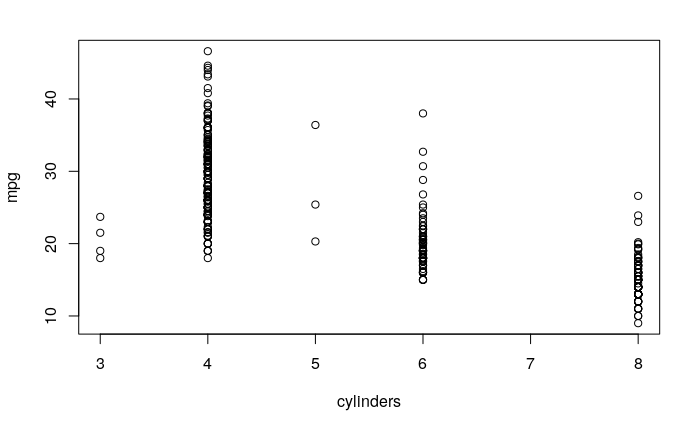

```r
attach(auto)
plot(cylinders, mpg)
```

jika kita tidak menggunakan fungsi attach(), maka kita harus menggunakan argument plot(auto$cylinders, auto$mpg)

```r
cylinders = as.factor(cylinders)
cylinders
```

```
  [1] 8 8 8 8 8 8 8 8 8 8 8 8 8 8 4 6 6 6 4 4 4 4 4 4 6 8 8 8 8 4 4 4 6 6 6 6 6 8 8 8 8 8 8 8 6 4
 [47] 6 6 4 4 4 4 4 4 4 4 4 4 4 4 4 8 8 8 8 8 8 8 8 8 3 8 8 8 8 4 4 4 4 4 4 4 4 4 8 8 8 8 8 8 8 8
 [93] 8 8 8 8 6 6 6 6 6 4 8 8 8 8 6 4 4 4 3 4 6 4 8 8 4 4 4 4 8 4 6 8 6 6 6 4 4 4 4 6 6 6 8 8 8 8
[139] 8 4 4 4 4 4 4 4 4 4 4 4 6 6 6 6 8 8 8 8 6 6 6 6 6 8 8 4 4 6 4 4 4 4 6 4 6 4 4 4 4 4 4 4 4 4
[185] 4 8 8 8 8 6 6 6 6 4 4 4 4 6 6 6 6 4 4 4 4 4 8 4 6 6 8 8 8 8 4 4 4 4 4 8 8 8 8 6 6 6 6 8 8 8
[231] 8 4 4 4 4 4 4 4 4 6 4 3 4 4 4 4 4 8 8 8 6 6 6 4 6 6 6 6 6 6 8 6 8 8 4 4 4 4 4 4 4 4 5 6 4 6
[277] 4 4 6 6 4 6 6 8 8 8 8 8 8 8 8 4 4 4 4 5 8 4 8 4 4 4 4 4 6 6 4 4 4 4 4 4 4 4 6 4 4 4 4 4 4 4
[323] 4 4 4 5 4 4 4 4 6 3 4 4 4 4 4 6 4 4 4 4 4 4 4 4 4 4 4 4 4 4 4 4 4 6 6 6 6 8 6 6 4 4 4 4 4 4
[369] 4 4 4 4 4 4 4 4 4 4 4 4 6 6 4 6 4 4 4 4 4 4 4 4
Levels: 3 4 5 6 8
```

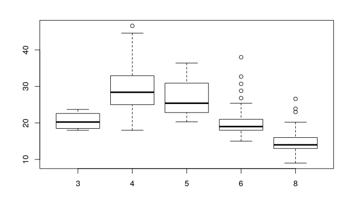

```r
plot(cylinders, mpg)
```

histogram plot

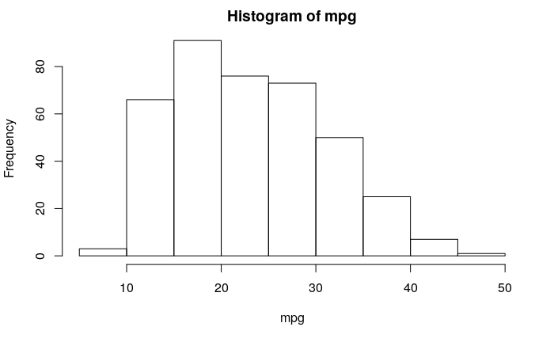

```r
hist(mpg)
```

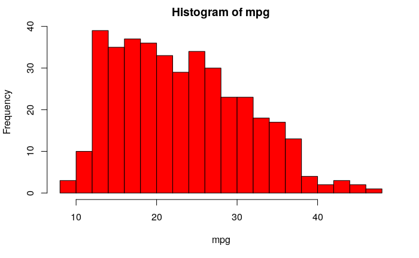

```r
hist(mpg, col=2, breaks=15)
```

Pairs untuk scatterplot

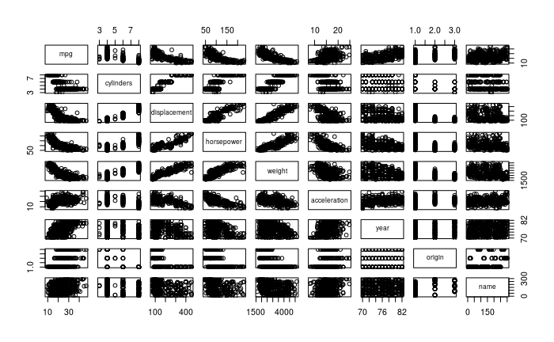

```r
pairs(auto)
```

pairs untuk beberapa variabel saja

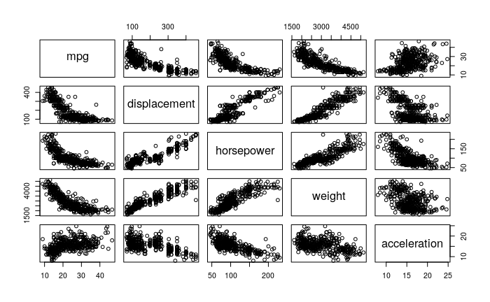

```r
pairs(~ mpg + displacement + horsepower + weight + acceleration, auto)
```

fungsi identify() untuk melihat hubungan beberapa variabel

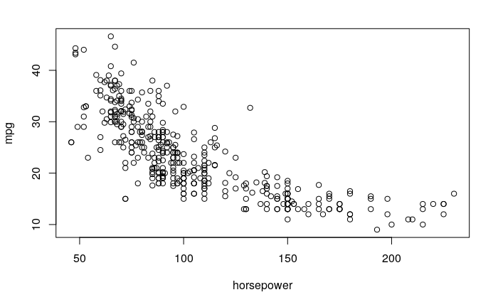

```r
plot(horsepower, mpg)
```

[output not shown]

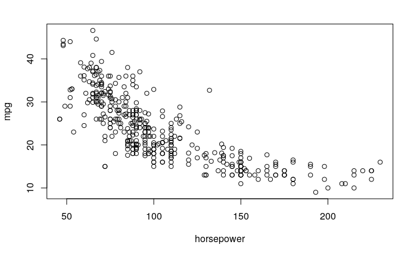

```r
plot(horsepower, mpg)
identify(horsepower, mpg, name)
```

summary data

```r
summary(auto)
```

```
      mpg          cylinders      displacement     horsepower        weight      acceleration
 Min.   : 9.00   Min.   :3.000   Min.   : 68.0   Min.   : 46.0   Min.   :1613   Min.   : 8.00
 1st Qu.:17.00   1st Qu.:4.000   1st Qu.:105.0   1st Qu.: 75.0   1st Qu.:2225   1st Qu.:13.78
 Median :22.75   Median :4.000   Median :151.0   Median : 93.5   Median :2804   Median :15.50
 Mean   :23.45   Mean   :5.472   Mean   :194.4   Mean   :104.5   Mean   :2978   Mean   :15.54
 3rd Qu.:29.00   3rd Qu.:8.000   3rd Qu.:275.8   3rd Qu.:126.0   3rd Qu.:3615   3rd Qu.:17.02
 Max.   :46.60   Max.   :8.000   Max.   :455.0   Max.   :230.0   Max.   :5140   Max.   :24.80

      year           origin                      name
 Min.   :70.00   Min.   :1.000   amc matador       :  5
 1st Qu.:73.00   1st Qu.:1.000   ford pinto        :  5
 Median :76.00   Median :1.000   toyota corolla    :  5
 Mean   :75.98   Mean   :1.577   amc gremlin       :  4
 3rd Qu.:79.00   3rd Qu.:2.000   amc hornet        :  4
 Max.   :82.00   Max.   :3.000   chevrolet chevette:  4
                                 (Other)           :365
```